# growth_sales_analysis_demo

Starting off with our analysis, importing and conducting EDA to better understand the data and general insights

```python
import pandas as pd
import json
import matplotlib.pyplot as plt
import matplotlib as mpl
mpl.rcParams['axes.prop_cycle'] = mpl.cycler(color=["#0052CC", "#172B4D", "#36B37E"])
import numpy as np
import seaborn as sns
import sqlite3
from sqlite3 import connect
conn = connect(':memory:')
```

## Background Information

Attached, are recent sales performance for a Sales Organization Enterprise. There are two tabs included:

- “Opportunities Closed Won / Lost” - the orange tab contains all deals the sales team closed as either won or lost.
- “Rep Tenures” - the blue tab contains a key for the different field sales reps and SDRs (that you will find referred to in the orange tab by Rep or SDR number) with how long they have been in the role.

The head of sales strategy has asked for an annual review of the business.

1. At the highest level, how did we perform in 2017?
2. What are specific areas of strength or weakness?
3. Strategically, how efficient is our sales org (SDRs and direct sellers)?
4. What other interesting considerations should we think about for 2018?

## EDA

To start we're conducting introductory data exploration and manipulation

```python
df1 = pd.read_csv('demo_growth_sales.csv')
#csv sheet from rep tenures doesn't look well formatted as a table. Taking the data and creating a new dataframe
#df2 = pd.read_csv('KY- Atlassian Final Round Case Study_ Dataset - Rep Tenures.csv')
#df2 field output isn't straightforward. Instead, creating the field sales rep data as a new dataframe
data2 = {
    'Field Sales Rep #': ['Field Sales Rep 1', 'Field Sales Rep 2', 'Field Sales Rep 3', 'Field Sales Rep 4', 'Field Sales Rep 5', 'Field Sales Rep 6', 'Field Sales Rep 7', 'Field Sales Rep 8', 'Field Sales Rep 9', 'Field Sales Rep 10', 'Field Sales Rep 11', 'Field Sales Rep 12'],
    'Start month in direct sales role': ['4/1/2016', '7/1/2015', '6/1/2015', '9/1/2017', '11/1/2016', '11/1/2017', '12/1/2016', '8/1/2017', '6/1/2017', '8/1/2017', '11/1/2016', '8/1/2017']
}
df2 = pd.DataFrame(data2)
#creating the SDR rep data as a new dataframe.
data3 = {
    'SDR #': [1, 2, 3, 4],
    'Start month in qualification role': ['11/1/2016', '7/1/2016', '6/1/2017', '8/1/2017']
}
df3 = pd.DataFrame(data3)

##previously we checked how many rows are excluded when we drop all NA values in the table. From the output, we see theres a discrepancy where 1652/1698 values have a NA Value. Therefore we can not drop the NAs as we'll remove valuable information from our analysis.
close_ops = df1.copy(deep=True)
close_ops.columns = close_ops.columns.str.replace(' ', '_')
close_ops.head()

rep_tenures = df2.copy(deep=True)
sdr_tenures = df3.copy(deep=True)
```

```python
#since our analysis is for an annual review of 2017, let's strip our table of all 2018 values.
filter = ~close_ops['Fiscal_Period'].str.contains('2018')
close_ops = close_ops[filter]
#confirming that there are 0 duplicates in the data - print(close_ops.duplicated().sum())
```

```python
#Looking at the data key, it looks like if a sale type is renewal, the lead source should always be renewal.
close_ops = close_ops[~((close_ops['Sale_Type'] == 'Renewal') & (close_ops['Lead_Source'] != 'Renewal'))]
close_ops = close_ops[close_ops['Product_SKU'].isin(['Enterprise', 'Business Class'])]
close_ops
```

|  | Opportunity_Name_Masked | Country | Sale_Type | Lead_Source | SDR | Amount | Product_SKU | Close_Date | Fiscal_Period | Age | Owner_Role | Account_Name_Masked | Stage | Opportunity_Owner |
| --- | --- | --- | --- | --- | --- | --- | --- | --- | --- | --- | --- | --- | --- | --- |
| 1 | Opportunity_8993 | NaN | New Business | Demo Form | SDR 1 | $7,500.00 | Enterprise | 6/22/2017 | Q2-2017 | 2 | Sales Rep | COMPANY_204 | Closed Won | Field Sales Rep 9 |
| 2 | Opportunity_5221 | NaN | New Business | Inbound | NaN | $5,000.00 | Enterprise | 6/30/2017 | Q2-2017 | 38 | Sales Rep | COMPANY_664 | Closed Lost | Field Sales Rep 9 |
| 3 | Opportunity_7882 | USA | New Business | Demo Form | NaN | $6,000.00 | Business Class | 8/3/2017 | Q3-2017 | 23 | Sales Rep | COMPANY_123 | Closed Won | Field Sales Rep 9 |
| 4 | Opportunity_4918 | NaN | New Business | NaN | NaN | $6,000.00 | Business Class | 8/4/2017 | Q3-2017 | 0 | Sales Rep | COMPANY_948 | Closed Won | Field Sales Rep 9 |
| 5 | Opportunity_8304 | UK | New Business | NaN | NaN | $5,000.00 | Enterprise | 8/9/2017 | Q3-2017 | 7 | Sales Rep | COMPANY_987 | Closed Won | Field Sales Rep 9 |
| ... | ... | ... | ... | ... | ... | ... | ... | ... | ... | ... | ... | ... | ... | ... |
| 1614 | Opportunity_1327 | NaN | New Business | NaN | NaN | $5,000.00 | Enterprise | 12/31/17 | Q4-2017 | 160 | Sales Rep | COMPANY_1091 | Closed Lost | Field Sales Rep 9 |
| 1615 | Opportunity_5801 | US | New Business | Demo Form | NaN | $5,000.00 | Enterprise | 12/31/17 | Q4-2017 | 79 | Sales Rep | COMPANY_913 | Closed Lost | Field Sales Rep 9 |
| 1616 | Opportunity_3201 | NaN | New Business | NaN | NaN | $25,000.00 | Enterprise | 12/31/17 | Q4-2017 | 142 | Sales Rep | COMPANY_239 | Closed Lost | Field Sales Rep 9 |
| 1618 | Opportunity_4257 | NaN | New Business | Demo Form | NaN | $5,000.00 | Enterprise | 12/31/17 | Q4-2017 | 108 | Sales Rep | COMPANY_75 | Closed Lost | Field Sales Rep 9 |
| 1619 | Opportunity_3064 | NaN | New Business | NaN | NaN | $12,500.00 | Enterprise | 12/31/17 | Q4-2017 | 115 | Sales Rep | COMPANY_1116 | Closed Lost | Field Sales Rep 9 |

1213 rows × 14 columns

```python
#evaluating SDRs by type of business.
sdr_sales = close_ops.groupby(['SDR', 'Sale_Type']).size().unstack()
print(sdr_sales)
#from this we're able to observe a small mix of information. Data cleanliness (i.e. FSR12 should not be here). SDR was not looped into Renewals. SDR was rarely brought into expansion business. Primarily worked within New Business.
```

```
Sale_Type           New Business  Expansion
SDR
Field Sales Rep 12           1.0        NaN
SDR 1                       50.0        2.0
SDR 2                       54.0        3.0
SDR 3                       22.0        NaN
SDR 4                        6.0        NaN
SDR 5                        1.0        NaN
SDR 6                        1.0        NaN
```

```
Sale_Type
Expansion        4421709
New Business    12310957
Renewal          3207276
Name: Amount, dtype: int64
```

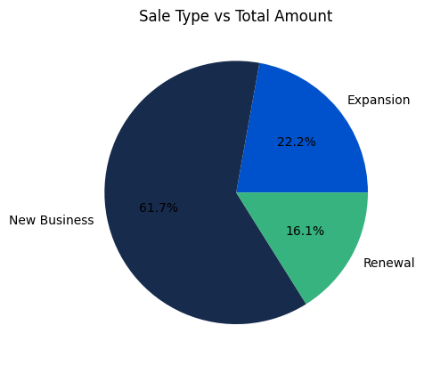

```python
#manipulating the data to remove NA values from Amounts and change the Object type of Amount to an interger so we can create visualizations.
close_ops['Amount'].dtypes
close_ops = close_ops.dropna(subset=['Amount'])

close_ops['Amount'] = close_ops['Amount'].replace(r'[\$,]', '', regex=True).astype(float).astype(int)
sale_amounts = close_ops.groupby('Sale_Type')['Amount'].sum()
print(sale_amounts)


sale_amounts.plot.pie(autopct='%1.1f%%')
plt.title('Sale Type vs Total Amount')
plt.ylabel('')
plt.show()
```

```
  Fiscal_Period  Total_Amount    Q_Growth
0       Q1-2017       1110593         NaN
1       Q2-2017       2324761  109.326099
2       Q3-2017       1737435  -25.263930
3       Q4-2017       2786823   60.398691
```

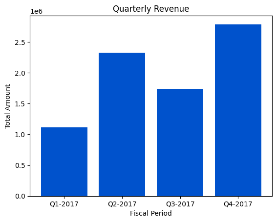

```python
#On a high level performance overview, let's understand how whether the business is growing in revenue quarter by quarter.
close_ops.to_sql(name='fiscal_revenue', con=conn, if_exists='replace')

#using a SQL query in order to reshape a new dataframe that targets the revenue metrics.
sql_string_1 = """
            SELECT
                Fiscal_Period,
                SUM(Amount) as Total_Amount
            FROM fiscal_revenue
            WHERE Stage in ('Closed Won')
            GROUP BY Fiscal_Period
            """

quarterly_revenue= pd.read_sql(sql_string_1, conn)

#calculating quarter over quarter revenue growth among the won deals
quarterly_revenue['Q_Growth'] = quarterly_revenue['Total_Amount'].pct_change() * 100
print(quarterly_revenue)


plt.bar(quarterly_revenue['Fiscal_Period'], quarterly_revenue['Total_Amount'])
plt.xlabel('Fiscal Period')
plt.ylabel('Total Amount')
plt.title('Quarterly Revenue')
plt.xticks(rotation=0)
plt.show()
```

```python
quarterly_revenue
```

|  | Fiscal_Period | Total_Amount | Q_Growth |
| --- | --- | --- | --- |
| 0 | Q1-2017 | 1110593 | NaN |
| 1 | Q2-2017 | 2324761 | 109.326099 |
| 2 | Q3-2017 | 1737435 | -25.263930 |
| 3 | Q4-2017 | 2786823 | 60.398691 |

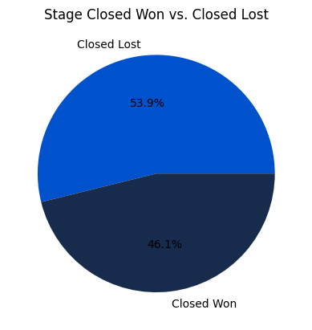

```python
won_lost = close_ops['Stage'].value_counts()

won_lost.plot.pie(autopct='%1.1f%%')
plt.title('Stage Closed Won vs. Closed Lost')
plt.ylabel('')
plt.show()
```

From here, in FY17 its noted that we have a high proportion of deals that were lost as opposed to won. Let's identify some factors that may have influenced the lost and won rate.

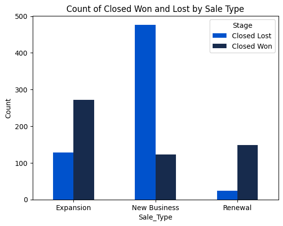

```python
stage_sale_type_counts = close_ops.groupby(['Sale_Type', 'Stage']).size().unstack()

stage_sale_type_counts.plot(kind='bar')
plt.title('Count of Closed Won and Lost by Sale Type')
plt.ylabel('Count')
plt.xticks(rotation=0)
plt.show()
```

From this visualization we're able to determine that the Expansion and Renewal Categories are doing well in their proportion of wins to losses. However, New Business has a significant discrepancy in the Lost/Won Rate. This should be the focus of our attention for optimization. If we have additional resources, we should also investigate and optimize the expansion category.

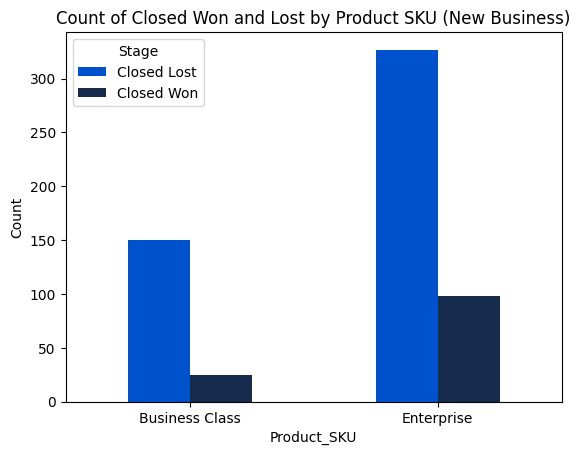

```python
#Isolating the dataframe for new business made.
new_business = close_ops[close_ops['Sale_Type'] == 'New Business']
new_business_close_props = new_business['Stage'].value_counts(normalize=True)*100

#Grouping the data by SKU (Enterprise/Business Class) and whether the deal was won or lost.
sku_stage_counts = new_business.groupby(['Product_SKU', 'Stage']).size().unstack()

sku_stage_counts.plot(kind='bar')
plt.title('Count of Closed Won and Lost by Product SKU (New Business)')
plt.ylabel('Count')
plt.xticks(rotation=0)
plt.show()

#Breakdown by of proportional won and lost for new enterprise and business class deals.
sku_stage_proportions = new_business.groupby('Product_SKU')['Stage'].value_counts(normalize=True).unstack() * 100
```

```python
sku_stage_proportions.loc[['Business Class', 'Enterprise']]
```

| Stage Product_SKU | Closed Lost | Closed Won |
| --- | --- | --- |
| Business Class | 85.714286 | 14.285714 |
| Enterprise | 76.941176 | 23.058824 |

From this analysis, we're able to see that proportionally the business class and enterprise new deals are both disproportionately lost. There's a larger share of business class that is lost (~9% discrepency). Though we don't know of the deviation or YoY change, we can start to dig deeper into this. Let's start by looking into a mixed matrix model in order to create an affinity analysis of the closed won and closed lost attributes.

## Investigating Attributes: Correlation

We'll conduct a simple affinity analysis to determine whether there is correlation among the different attributes that may be influencing our deal close. Based on this frequency analysis, we'll be able to see a few trends that would provide **direction for further analysis**. If there is a positive correlation, this indicates that as the frequency of one attribute occurs, the frequency of the other attribute tends to be present, negative indicates that increased frequency in one attribute is reflected with a decrease in frequency of other attributes.

```
                      Stage   Country       SDR  Opportunity_Owner  \
Stage              1.000000  0.361349 -0.060855           0.095707
Country            0.361349  1.000000 -0.069796           0.178329
SDR               -0.060855 -0.069796  1.000000          -0.105833
Opportunity_Owner  0.095707  0.178329 -0.105833           1.000000
Fiscal_Period      0.015931 -0.097427  0.055875           0.013015
Lead_Source       -0.135124 -0.092366  0.099557          -0.092921
ranking            0.391443  0.134724  0.001234          -0.011124

                   Fiscal_Period  Lead_Source   ranking
Stage                   0.015931    -0.135124  0.391443
Country                -0.097427    -0.092366  0.134724
SDR                     0.055875     0.099557  0.001234
Opportunity_Owner       0.013015    -0.092921 -0.011124
Fiscal_Period           1.000000    -0.043044  0.543441
Lead_Source            -0.043044     1.000000 -0.035260
ranking                 0.543441    -0.035260  1.000000
```

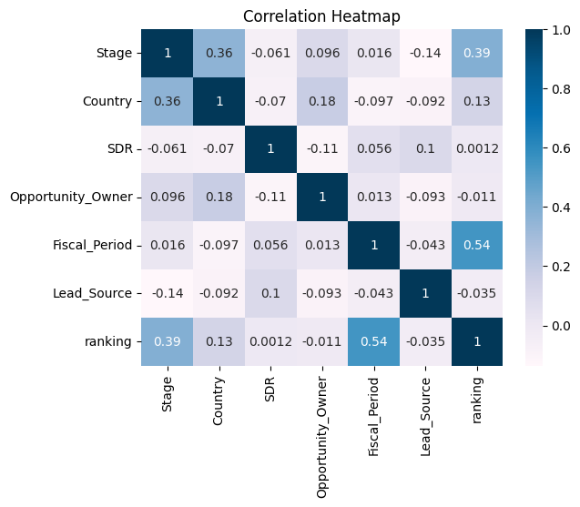

```python
# For New Business Stage Closed Won and Closed Lost, what are the most common attributes of Country, SDR, Opportunity Owner, Fiscal Period, and Lead Source?
new_business.to_sql(name='new_business_sql', con=conn, if_exists='replace')

#using a SQL query in order to reshape a new dataframe that contains information that would better shape our understanding of performance.
sql_string = """
            SELECT
                Stage,
                Country,
                SDR,
                Opportunity_Owner,
                Fiscal_Period,
                Lead_Source,
                rank() over(partition by Stage order by Close_Date ASC) as ranking
            FROM new_business_sql
            WHERE Stage in ('Closed Won', 'Closed Lost')
            """

deal_corr= pd.read_sql(sql_string, conn)

#creating a correlation table among the different attributes to identify which ones influence each other.
deal_matrix = deal_corr.apply(lambda x: x.factorize()[0]).corr()
print(deal_matrix)
#corr is a simple relational analysis between frequency of occurance together yielding a result. + numbers indicate that if one trends in a positive frequency, so does the other. If one trends in a positive frequency, the other trends toward a negative frequency.


#Plotting a correlation matrix to identify the factors that influence each other
sns.heatmap(deal_matrix, annot=True, cmap='PuBu')
plt.title('Correlation Heatmap')
plt.show()
```

As our data is categorical with many features for each attribute, we can't say the correlation matrix is a definitive. However, this does give us direction on what we should investigate. Aside from rank (previously queried to rank by the close date), we'll take a better look at attributes associated with Stage and each other by ~ +- 0.1.  
Therefore we'll investigate:

- Stage & Lead Source
- Stage & Opportunity Owner
- Stage & Country

For brevity, we will leave a full analysis for later. Though it would be worth investigating the following attributes and their relations:

- Country & Fiscal Period
- Country & Opportunity Owner
- SDR & Lead Source
- SDR & Opportunity Owner
- Opportunity Owner & Lead_Source
- Opportunity Owner & SDR

An example of this investigation: Does a Opportunity Owner (sales) often impact a deal when a SDR is not present or specific pairings are made?

### Opportunity Stage (Closed Won/Lost) for New Business Sale Type by Lead Source

Preliminary investigation to identify how lead sources are impacting the New Business Sale types

```
Stage                                    Closed Lost  Closed Won
Lead_Source
Inbound                                        203.0        50.0
Demo Form                                       86.0        40.0
Outbound                                        69.0        10.0
Support Escalation                              32.0         7.0
Auto - new account creation                     31.0         2.0
PQL                                              6.0         2.0
10 User Threshold                                3.0         1.0
Others                                           1.0         1.0
Webinar                                          8.0         1.0
Client Dinner                                    1.0         NaN
Co-Marketing                                     1.0         NaN
Conference                                       2.0         NaN
Employee Referral                                1.0         NaN
Event                                            4.0         NaN
External Referral                                2.0         NaN
HubSpot                                          4.0         NaN
Marketing Campaign                               1.0         NaN
Renewal                                          2.0         NaN
Webinar - Trello App For Slack - 062816          1.0         NaN
```

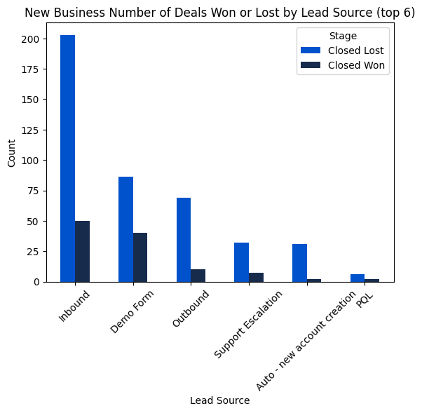

| Stage Lead_Source | Closed Lost | Closed Won | Win Ratio |
| --- | --- | --- | --- |
| Demo Form | 86.0 | 40.0 | 0.317460 |
| PQL | 6.0 | 2.0 | 0.250000 |
| Inbound | 203.0 | 50.0 | 0.197628 |
| Support Escalation | 32.0 | 7.0 | 0.179487 |
| Outbound | 69.0 | 10.0 | 0.126582 |
| Auto - new account creation | 31.0 | 2.0 | 0.060606 |

```python
# Group by 'Lead_Source' and 'Stage' and count the number of deals and sort with highest #won on top.
stage_counts = new_business.groupby(['Lead_Source', 'Stage']).size().unstack().sort_values('Closed Won', ascending=False)
print(stage_counts)
#isolating by the top 6 to graph.
top_6_won_lead_sources = stage_counts.head(6)

# Plotting a bar graph to compare the lost and won for each lead source.
top_6_won_lead_sources.plot(kind='bar')
plt.xlabel('Lead Source')
plt.ylabel('Count')
plt.title('New Business Number of Deals Won or Lost by Lead Source (top 6)')
plt.xticks(rotation=45)
plt.show()

#calculate the won/lost percentages for each of the top 6 won leads
top_6_won_lead_sources_ratio = top_6_won_lead_sources.copy()
top_6_won_lead_sources_ratio.loc[:, 'Win Ratio'] = top_6_won_lead_sources_ratio['Closed Won'] / (top_6_won_lead_sources_ratio['Closed Won'] + top_6_won_lead_sources_ratio['Closed Lost'])
top_6_won_lead_sources_ratio.sort_values('Win Ratio', ascending=False)
```

By setting our analysis to focus on the successful closed deals within the new business category, we're able to isolate how effective our sales strategy is for each lead source conversion. We see that our most effective win ratio is the Demo Form. This is where we can drive people closer to the consideration phase and increase our demand generation/marketing strategy to encourage more demos. On the other hand, its worthwhile investigating the inbound, support esclation, outbound, and auto nurture flows to identify how we can increase understandings of our customer needs at these points and to drive higher engagement and conversions.

```
Stage               Closed Lost  Closed Won
Opportunity_Owner
Field Sales Rep 5         140.0        29.0
Field Sales Rep 6          86.0        28.0
Field Sales Rep 2          93.0        25.0
Field Sales Rep 9          48.0        17.0
Field Sales Rep 3          12.0         7.0
Field Sales Rep 8           NaN         6.0
Field Sales Rep 12         49.0         4.0
Field Sales Rep 4          17.0         4.0
Field Sales Rep 10         22.0         2.0
Field Sales Rep 1           6.0         1.0
Field Sales Rep 11          4.0         NaN
```

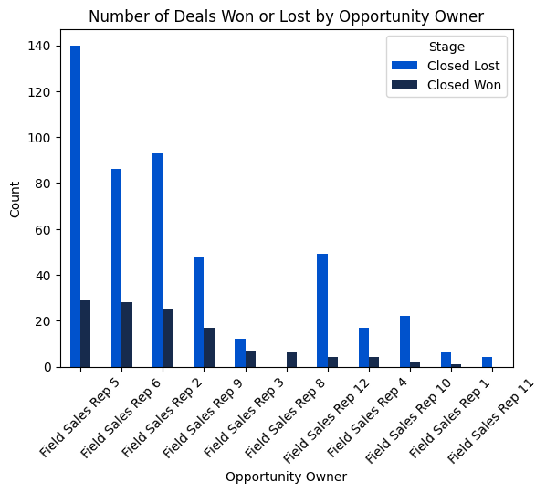

| Stage Opportunity_Owner | Closed Lost | Closed Won | Deals | Win Ratio |
| --- | --- | --- | --- | --- |
| Field Sales Rep 3 | 12.0 | 7.0 | 19.0 | 0.368421 |
| Field Sales Rep 9 | 48.0 | 17.0 | 65.0 | 0.261538 |
| Field Sales Rep 6 | 86.0 | 28.0 | 114.0 | 0.245614 |
| Field Sales Rep 2 | 93.0 | 25.0 | 118.0 | 0.211864 |
| Field Sales Rep 4 | 17.0 | 4.0 | 21.0 | 0.190476 |
| Field Sales Rep 5 | 140.0 | 29.0 | 169.0 | 0.171598 |
| Field Sales Rep 1 | 6.0 | 1.0 | 7.0 | 0.142857 |
| Field Sales Rep 10 | 22.0 | 2.0 | 24.0 | 0.083333 |
| Field Sales Rep 12 | 49.0 | 4.0 | 53.0 | 0.075472 |
| Field Sales Rep 8 | NaN | 6.0 | NaN | NaN |
| Field Sales Rep 11 | 4.0 | NaN | NaN | NaN |

```python
# Group by 'Opportunity_Owner' (Sales Rep Closing Deal) and 'Stage' and count the number of deals and sort with highest #won on top.
owner_wins = new_business.groupby(['Opportunity_Owner', 'Stage']).size().unstack().sort_values('Closed Won', ascending=False)
print(owner_wins)


# Plotting a bar graph to compare the lost and won for each opportunity owner.
owner_wins.plot(kind='bar')
plt.xlabel('Opportunity Owner')
plt.ylabel('Count')
plt.title('Number of Deals Won or Lost by Opportunity Owner')
plt.xticks(rotation=45)
plt.show()

# Calculate the won/lost percentages for each of the opportunity owners
owner_wins_ratio = owner_wins.copy()
owner_wins_ratio['Deals'] = owner_wins_ratio['Closed Won'] + owner_wins_ratio['Closed Lost']
owner_wins_ratio.loc[:, 'Win Ratio'] = owner_wins['Closed Won'] / (owner_wins['Closed Won'] + owner_wins['Closed Lost'])
owner_wins_ratio.sort_values('Win Ratio', ascending=False)
```

```python
#evaluating efficiency of Sales Reps in their win ratio and total Cases
owner_wins_ratio.to_sql(name='owner_wins_sql', con=conn, if_exists='replace')
rep_tenures.to_sql(name='rep_tenures_sql', con=conn, if_exists='replace')

#using a SQL query in order to reshape a new dataframe that contains information that would better shape our understanding of performance.
sql_string_2 = """
SELECT owner_wins_sql.*, rep_tenures_sql.`Start month in direct sales role`
FROM owner_wins_sql
JOIN rep_tenures_sql
ON owner_wins_sql.Opportunity_owner = rep_tenures_sql.`Field Sales Rep #`
ORDER BY owner_wins_sql.`Win Ratio` DESC
"""

rep_efficiency= pd.read_sql(sql_string_2, conn)
rep_efficiency
```

|  | Opportunity_Owner | Closed Lost | Closed Won | Deals | Win Ratio | Start month in direct sales role |
| --- | --- | --- | --- | --- | --- | --- |
| 0 | Field Sales Rep 3 | 12.0 | 7.0 | 19.0 | 0.368421 | 6/1/2015 |
| 1 | Field Sales Rep 9 | 48.0 | 17.0 | 65.0 | 0.261538 | 6/1/2017 |
| 2 | Field Sales Rep 6 | 86.0 | 28.0 | 114.0 | 0.245614 | 11/1/2017 |
| 3 | Field Sales Rep 2 | 93.0 | 25.0 | 118.0 | 0.211864 | 7/1/2015 |
| 4 | Field Sales Rep 4 | 17.0 | 4.0 | 21.0 | 0.190476 | 9/1/2017 |
| 5 | Field Sales Rep 5 | 140.0 | 29.0 | 169.0 | 0.171598 | 11/1/2016 |
| 6 | Field Sales Rep 1 | 6.0 | 1.0 | 7.0 | 0.142857 | 4/1/2016 |
| 7 | Field Sales Rep 10 | 22.0 | 2.0 | 24.0 | 0.083333 | 8/1/2017 |
| 8 | Field Sales Rep 12 | 49.0 | 4.0 | 53.0 | 0.075472 | 8/1/2017 |
| 9 | Field Sales Rep 8 | NaN | 6.0 | NaN | NaN | 8/1/2017 |
| 10 | Field Sales Rep 11 | 4.0 | NaN | NaN | NaN | 11/1/2016 |